# Can a Machine-Based Sommalier predict exceptional wine?

Using 150,000 wine reviews, can we predict a 90+ point wine?

Some examples of potential uses of such a model include:

1. Prioritizing of wine production
2. Purchasing decisions
3. Determining changing wine preferences over time

## Data

The wine review data used for point predictions is sourced from Kaggle's "Wine Review Data" set located [here](https://www.kaggle.com/zynicide/wine-reviews/data)

The data was scraped from WineEnthusiast on November 22nd, 2017. As a guide for the points system, Wine Spectator magazine, one of the largest wine scoring operations, indicates the following qualitative rating by score*:

- 60-69. Wines are flawed and not recommended
- 70-79 Wines are flawed and taste average
- 80-84 wines are above average to good
- 85-90 wines are good to very good
- 90-94 wines are superior to exceptional
- 95-100. Wines are benchmark examples or classic

*The data is only comprised of wines with ratings of 80 and above

## Goals

1. Train a classifier to determine whether or not a bottle of wine is exceptional (90+).
2. Understand what makes a wine exceptional (feature exploration).
3. Explore whether or not we can go further than a classifier, and instead use a regressor to predict points.

## Approach

1. Visualizing and quantifying relationships in the data to better understand common point values, prices, varieties, and countries and/or regions. This will also help inform whether or not 90 is an appropriate cutoff point
2. Preprocessing text-based features by introducing metadata features. Additionally, we will utilize a natural language processing technique known as Term frequency inverse document frequency (TF-IDF) to extract the words that best summarize the descriptions
3. Exploring several classifiers including Naive Bayes, Logistic Regression,Gradient Boost, Random Forest, and a voting ensemle of all three.
4. Testing whether or not automated feature selection of PCA is helpful in increasing performance and/or generalizability of the model.
5. Testing which classifier hyperparameters help best to achieve increased performance and/or generalizability of the model.
6. Testing how the model performs when removing key features such as price.
7. Testing regressors to determine a baseline for regressor performance.

## Steps

1. Load the data
2. Visualize by country, variety, price, and point assignment
3. Add features for text
4. Test Classifiers: Naive Bayes, Logistic Regression, Random Forest, and voting ensemble of all three
5. Analyze important features
6. Model selection
7. Conclusion & Future steps

```python
import pandas as pd
import matplotlib.pyplot as plt
import numpy as np
import seaborn as sns
import math

from nltk.corpus import stopwords
from textblob import TextBlob
from textblob import Word
from sklearn.feature_extraction.text import TfidfVectorizer
from sklearn.model_selection import train_test_split

from sklearn.naive_bayes import BernoulliNB
from sklearn.pipeline import Pipeline
from sklearn.metrics import mean_squared_error, f1_score, accuracy_score, classification_report
from sklearn.linear_model import LogisticRegression
from sklearn import ensemble
from sklearn.model_selection import cross_val_score
from sklearn.preprocessing import StandardScaler

from sklearn.decomposition import PCA
from sklearn.svm import SVC
from sklearn.svm import SVR
from sklearn.svm import LinearSVC
from sklearn.feature_selection import SelectFromModel
from sklearn.metrics import r2_score
from sklearn.metrics import accuracy_score
from sklearn.linear_model import LinearRegression, Ridge
from sklearn.model_selection import GridSearchCV

import time
import pickle
import os

%matplotlib inline
```

## Step 1: Load the data

There are 150,930 reviews. Since 90+ wines are considered "superior to exceptional", I added a flag to indicate wines with a 90+ rating. Also, I filled in the mean price for wines where price was missing (13,695 or 9%).

```python
#Load the data
df = pd.read_csv('winemag-data_first150k.csv')

#Insert column to flag "Exceptional wines"
df['is_exceptional'] = np.where(df['points']>=90, 1, 0)

#set null prices to the mean price
df.loc[pd.isnull(df.price),'price']=df.price.mean()
```

## Step 2: Visualize by country, variety, price, and point assignment

- Wine in this dataset is dominated by about 10 countries, where conditions are favorable for grapes
- Chardonnay, Pinot Noir, Cabernet Sauvignon, and a Red Blend are the most popular wine varieties
- The highest priced wine in the dataset is a \$2,300 Bordeaux-style Red Blend (99 points), while the lowest priced wine is a \$4 Merlot (86 points). The average price of a bottle of wine in the dataset was \$33
- There is a positively correlated relationship between price and points of .44.
- The average point value assigned is 88, and approximately 68% of the wine bottles are rated below 90

```
Text(0.5,1,'Wines counts by Country')
```

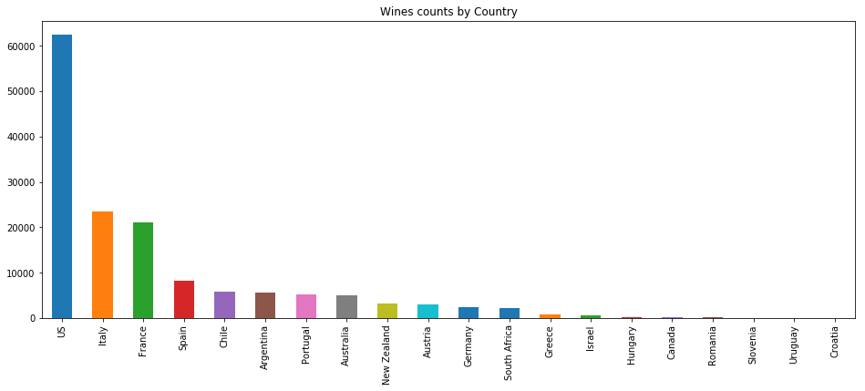

```python
# bar plot
plt.figure(figsize=(16,6))
df['country'].value_counts().head(20).plot.bar()
plt.title('Wines counts by Country')
#Wine in this dataset is dominated by about 10 countries, where conditions are favorable for grapes
```

```
Text(0.5,1,'Wines counts by Top 20 varieties')
```

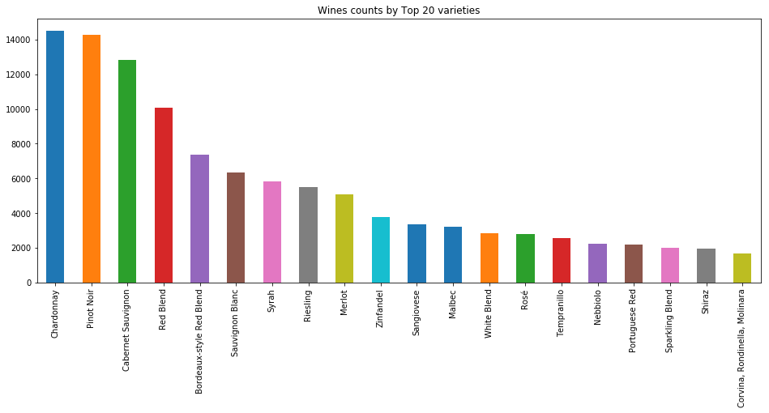

```python
# bar plot
plt.figure(figsize=(16,6))
df['variety'].value_counts().head(20).plot.bar()
plt.title('Wines counts by Top 20 varieties')
#Wine in this dataset is dominated by about 10 countries, where conditions are favorable for grapes
```

```
Average Price: 33.13148249353165
```

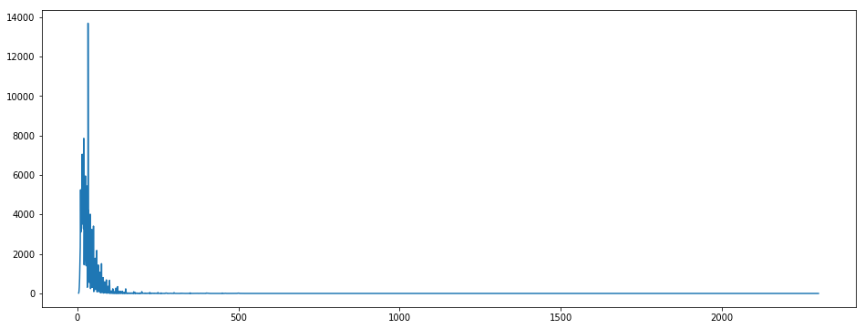

```python
#Plot Price
plt.figure(figsize=(16,6))
df['price'].value_counts().sort_index().plot.line()
print('Average Price: {}'.format(df['price'].mean()))
#The highest priced wine in the dataset is a $2,300 Bordeaux-style Red Blend (99 points),
#while the lowest priced wine is a $4 Merlot (86 points).  The average price of a bottle of wine in the dataset was $33
```

```
Correlation:  0.4384070024187359
```

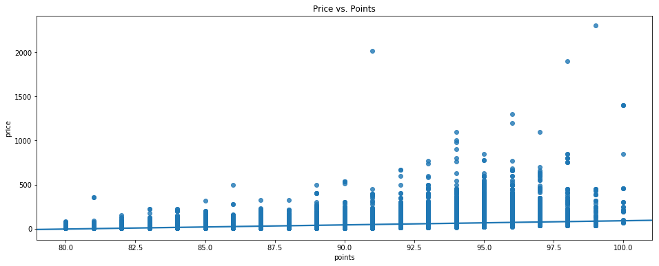

```python
#Scatter plot for Prive vs. Points
plt.figure(figsize=(16,6))
sns.regplot(x='points', y='price', data=df)
plt.title('Price vs. Points')

print('Correlation:  {}'.format(df['price'].corr(df['points'])))
```

```
Mean: 87.8884184721394
Median: 88.0
Mode: 87
```

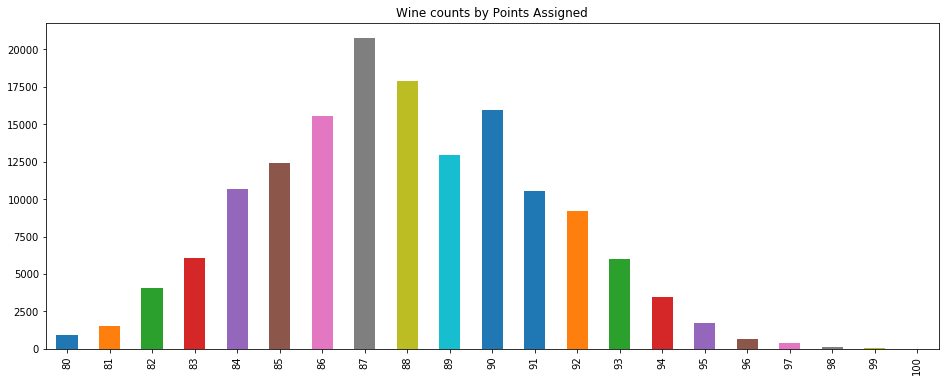

```python
#Histogram of Points
plt.figure(figsize=(16,6))
df['points'].value_counts().sort_index().plot.bar()
plt.title('Wine counts by Points Assigned')

#Print mean/median/mode
print('Mean: {}'.format(df['points'].mean()))
print('Median: {}'.format(df['points'].median()))
print('Mode: {}'.format(df['points'].mode().iloc[0]))
```

```
 <a list of 2 Text xticklabel objects>)
```

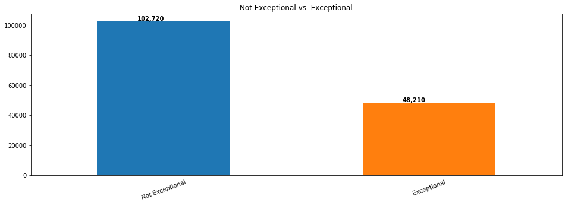

```python
#Not Exceptional vs. Exceptional
plt.figure(figsize=(16,5))
ax = df['is_exceptional'].value_counts().sort_index().plot.bar()
y =  df.groupby(['is_exceptional']).size()
y = [str(x) for x in y.tolist()]

#print counts on bar
for i, v in enumerate(y):
    ax.text(i-.1, int(v)+500, '{:,}'.format(int(v)), color='black', fontweight='bold')

xaxis_labels = ['Not Exceptional','Exceptional']

plt.title('Not Exceptional vs. Exceptional')
plt.xticks(np.arange(2),xaxis_labels , rotation=20)
#The average point value assigned is 88, and approximately 68% of the wine bottles are rated below 90
```

```
Text(0.5,1,'Top 10 Varieties Density Plot')
```

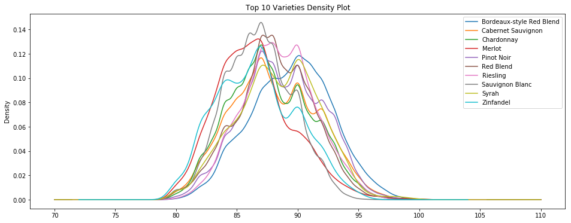

```python
#See if there are any differences in point distributions by wine variety
plt.figure(figsize=(16,6))
top_10 = df.groupby(['variety']).size().nlargest(10)
df[df['variety'].isin(top_10.index)].groupby(df.variety).points.plot.kde()
plt.legend()
plt.title('Top 10 Varieties Density Plot')
```

```
Text(0.5,1,'Top 10 Countries Density Plot')
```

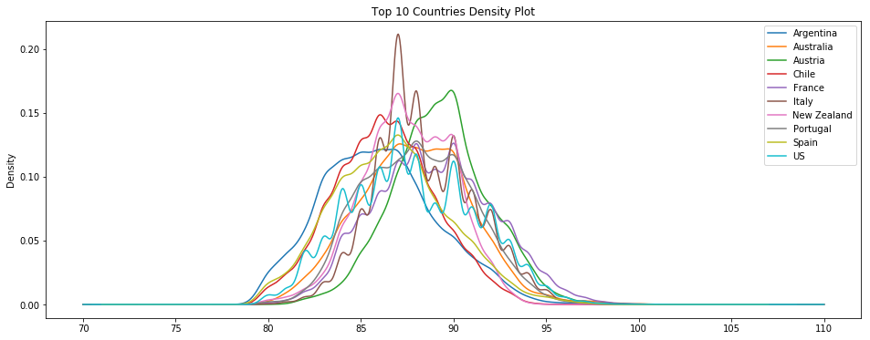

```python
#See if there are any differences in point distributions by country
plt.figure(figsize=(16,6))
top_10 = df.groupby(['country']).size().nlargest(10)
df[df['country'].isin(top_10.index)].groupby(df.country).points.plot.kde()
plt.legend()
plt.title('Top 10 Countries Density Plot')
```

## Step 3: Add features for text

The description column offers a few sentences about the wine. I used this to create several new features such as:

- Word count
- Character count
- Average number of words
- Number of stop words (commonly used word (such as "the") to ignore based on the english dictionary)
- Number of numbers
- Number of percents

I then created dummy variables for the remaining columns (excluding description). I also added designation and winery to the description since there were many variations and this created tens of thousands of new dummy variables, and thus memory errors.

Finally, I used a TFIDF vectorizer on the newly created description column (that now includes winery and designation) to take the top 1,000 words from the description and create columns for each word.

```python
#avg word function
def avg_word(sentence):
  words = sentence.split()
  return (sum(len(word) for word in words)/len(words))
```

```python
##Add feaures

#df.reset_index(drop=True, inplace=True)

#text features
stop = stopwords.words('english')

df['word_count'] = df['description'].apply(lambda x: len(str(x).split(" ")))
df['char_count'] = df['description'].str.len() ## this also includes spaces
df['avg_word'] = df['description'].apply(lambda x: avg_word(x))
df['stopwords'] = df['description'].apply(lambda x: len([x for x in x.split() if x in stop]))
df['numerics'] = df['description'].apply(lambda x: len([x for x in x.split() if x.isdigit()]))
df['percent'] = df['description'].apply(lambda x: len([x for x in x.split() if x.endswith('%')]))

#description processing
df['description'] = df['description'].apply(lambda x: " ".join(x.lower() for x in x.split()))
df['description'] = df['description'].str.replace('[^\w\s]','')
df['description'] = df['description'].apply(lambda x: " ".join(x for x in x.split() if x not in stop))

#combine description and designation into 1 column
df['description'] = df['designation'].astype(str) + ' ' + df['winery'] + ' ' + df['description']

#get rid of description so you can get dummies
df_description = df[['description']]
df.drop(['Unnamed: 0','description','designation','winery'], axis=1, inplace=True)
df = pd.get_dummies(df)


#Create tfidf features
tfidf = TfidfVectorizer(max_features=1000, lowercase=True, analyzer='word',
stop_words= 'english',ngram_range=(1,1))
vect = tfidf.fit_transform(df_description['description'])

columns = tfidf.get_feature_names()
a = vect.toarray()

df2 = pd.DataFrame(np.reshape(a, (len(a),vect.shape[1])),columns=columns)
df = pd.concat([df, df2],axis=1)

#Definine outcome and predictors.
y = df['is_exceptional']
X = df.loc[:, ~df.columns.isin(['is_exceptional','points'])]

#Definine outcome and predictors with price removed.
y_np = df['is_exceptional']
X_np = df.loc[:, ~df.columns.isin(['is_exceptional','points','price'])]

df.head()
```

## Step 4: Test classifiers

While the highest f1-score on the test set is most important, it's also important to consider the results on the training set to determine if the model is perhaps overfitting or not generalized enough. An ideal model, therefore, would have a high f1-score with little difference between the training and test set.

[figure not shown]

```python
from IPython.display import Image

Image(filename='image.png')
```

```python
#Naive Bayes
rf_filename = r'naive_bayes.pkl'
pipeline = run_model('Naive Bayes', rf_filename, False, False, 0, BernoulliNB())
```

```
Naive Bayes
Training set:
             precision    recall  f1-score   support

          0       0.90      0.83      0.86     71916
          1       0.69      0.80      0.74     33735

avg / total       0.83      0.82      0.83    105651

Test set:
             precision    recall  f1-score   support

          0       0.90      0.83      0.86     30804
          1       0.69      0.79      0.74     14475

avg / total       0.83      0.82      0.82     45279

Accuracy:  0.8206895028600455
--- 45.21098303794861 seconds ---
```

```python
#Logistic Regression
rf_filename = r'logistic_regression.pkl'
pipeline = run_model('Logistic Regression', rf_filename, False, False, 0, LogisticRegression(C=1e9, n_jobs=-1))

#Get coefficients from Logistic Regression
coeffs_lr = list(sorted(zip(pipeline.named_steps['classifier'].coef_[0], X_train.columns),reverse=True))
coeffs_lr_bad = list(sorted(zip(pipeline.named_steps['classifier'].coef_[0], X_train.columns),reverse=False))
```

```
Logistic Regression
Training set:
             precision    recall  f1-score   support

          0       0.90      0.92      0.91     71916
          1       0.83      0.79      0.81     33735

avg / total       0.88      0.88      0.88    105651

Test set:
             precision    recall  f1-score   support

          0       0.89      0.91      0.90     30804
          1       0.81      0.76      0.78     14475

avg / total       0.86      0.87      0.86     45279

Accuracy:  0.8656772455222068
--- 21.998245000839233 seconds ---
```

```python
#Try Gradient Boost
rf_filename = r'gradient_boost_ne100_md5_lr99.pkl'
params = {'n_estimators': 100,'max_depth': 5,'loss': 'deviance','learning_rate': .99}
pipeline = run_model('Gradient Boost with 100 estimators, max depth of 5', rf_filename, False, False, 0, ensemble.GradientBoostingClassifier(**params))
```

```
Gradient Boost with 100 estimators, max depth of 5
Training set:
             precision    recall  f1-score   support

          0       0.93      0.94      0.94     71916
          1       0.88      0.84      0.86     33735

avg / total       0.91      0.91      0.91    105651

Test set:
             precision    recall  f1-score   support

          0       0.90      0.92      0.91     30804
          1       0.81      0.77      0.79     14475

avg / total       0.87      0.87      0.87     45279

Accuracy:  0.8708452041785375
--- 27.052549839019775 seconds ---
```

```python
#Try a Support Vector machine classifier
rf_filename = r'svc.pkl'
pipeline = run_model('Support Vector Classifier', rf_filename, False, False, 0, SVC())
```

```
Support Vector Classifier
Training set:
             precision    recall  f1-score   support

          0       0.94      0.96      0.95     71916
          1       0.92      0.87      0.90     33735

avg / total       0.93      0.93      0.93    105651

Test set:
             precision    recall  f1-score   support

          0       0.90      0.94      0.92     30804
          1       0.86      0.79      0.82     14475

avg / total       0.89      0.89      0.89     45279

Accuracy:  0.889087656529517
--- 37771.2895629406 seconds ---
```

```python
#Random Forest
rf_filename = r'random_forest.pkl'
pipeline = run_model('Random Forest', rf_filename, False, False, 0, ensemble.RandomForestClassifier(n_jobs=-1))
```

```
Random Forest
Training set:
             precision    recall  f1-score   support

          0       0.99      1.00      1.00     71916
          1       1.00      0.98      0.99     33735

avg / total       0.99      0.99      0.99    105651

Test set:
             precision    recall  f1-score   support

          0       0.90      0.96      0.93     30804
          1       0.90      0.76      0.83     14475

avg / total       0.90      0.90      0.90     45279

Accuracy:  0.8978776033039599
--- 19.478703260421753 seconds ---
```

## Attempting feature selection and PCA

Since the random forest performed best on the test set, I attempted feature selection and PCA to see if I could build a more generalizable model where the f1-score for the training set and test set would converge. I started with feature selection and PCA of 100, 250, 500, and 1000. This had the effect of lowering the f1-score for both the training and test set.

```python
#Try Random Forest with feature selection and PCA 100
rf_filename = r'random_forest_fs_100.pkl'
pipeline = run_model('Random Forest with Feature selection and PCA (100)', rf_filename, True, True, 100, ensemble.RandomForestClassifier(n_jobs=-1))
```

[output not shown]

```python
#Try Random Forest with feature selection and PCA 250
rf_filename = r'random_forest_fs_250.pkl'
pipeline = run_model('Random Forest with Feature selection and PCA (250)', rf_filename, True, True, 250, ensemble.RandomForestClassifier(n_jobs=-1))
```

```
Random Forest with Feature selection and PCA (250)
Training set:
             precision    recall  f1-score   support

          0       0.98      1.00      0.99     71916
          1       0.99      0.95      0.97     33735

avg / total       0.98      0.98      0.98    105651

Test set:
             precision    recall  f1-score   support

          0       0.88      0.96      0.92     30804
          1       0.89      0.72      0.79     14475

avg / total       0.88      0.88      0.88     45279

Accuracy:  0.8803197950484772
--- 3584.319991827011 seconds ---
```

```python
#Try Random Forest with feature selection and PCA 500
rf_filename = r'random_forest_fs_500.pkl'
pipeline = run_model('Random Forest with Feature selection and PCA (500)', rf_filename, True, True, 500, ensemble.RandomForestClassifier(n_jobs=-1))
```

```
Random Forest with Feature selection and PCA (500)
Training set:
             precision    recall  f1-score   support

          0       0.96      0.99      0.98     71916
          1       0.99      0.91      0.95     33735

avg / total       0.97      0.97      0.97    105651

Test set:
             precision    recall  f1-score   support

          0       0.86      0.96      0.91     30804
          1       0.88      0.67      0.76     14475

avg / total       0.87      0.87      0.86     45279

Accuracy:  0.8663177190308973
--- 30.785135507583618 seconds ---
```

```python
#Try Random Forest with feature selection and PCA 1000
rf_filename = r'random_forest_fs_1000.pkl'
pipeline = run_model('Random Forest with Feature selection and PCA (1000)', rf_filename, True, True, 1000, ensemble.RandomForestClassifier(n_jobs=-1))
```

```
Random Forest with Feature selection and PCA (1000)
Training set:
             precision    recall  f1-score   support

          0       0.97      1.00      0.98     71916
          1       0.99      0.93      0.96     33735

avg / total       0.98      0.97      0.97    105651

Test set:
             precision    recall  f1-score   support

          0       0.86      0.96      0.90     30804
          1       0.88      0.66      0.75     14475

avg / total       0.86      0.86      0.86     45279

Accuracy:  0.8618344044700634
--- 40.65083932876587 seconds ---
```

## Attempting PCA without feature selection

I then attempted PCA without feature selection for 2000 and 3000 components. Once again, this reduced the f1-score slightly for the training set, and did not improve the f1-score for the test set. As a result, I concluded that feature selection and PCA would not be useful for increasing model performance and generalizability.

```python
#Try Random Forest without feature selection and PCA 2000
rf_filename = r'random_forest_2000.pkl'
pipeline = run_model('Random Forest with PCA (2000)', rf_filename, False, True, 2000, ensemble.RandomForestClassifier(n_jobs=-1))
```

```
Random Forest with PCA (2000)
Training set:
             precision    recall  f1-score   support

          0       0.97      1.00      0.98     71916
          1       1.00      0.93      0.96     33735

avg / total       0.98      0.98      0.98    105651

Test set:
             precision    recall  f1-score   support

          0       0.85      0.96      0.90     30804
          1       0.88      0.64      0.74     14475

avg / total       0.86      0.86      0.85     45279

Accuracy:  0.8561584840654608
--- 65.66791224479675 seconds ---
```

```python
#Try Random Forest without feature selection and PCA 3000
rf_filename = r'random_forest_3000.pkl'
pipeline = run_model('Random Forest with PCA (3000)', rf_filename, False, True, 3000, ensemble.RandomForestClassifier(n_jobs=-1))
```

```
Random Forest with PCA (3000)
Training set:
             precision    recall  f1-score   support

          0       0.99      1.00      0.99     71916
          1       1.00      0.98      0.99     33735

avg / total       0.99      0.99      0.99    105651

Test set:
             precision    recall  f1-score   support

          0       0.85      0.96      0.90     30804
          1       0.89      0.65      0.75     14475

avg / total       0.86      0.86      0.85     45279

Accuracy:  0.8601338368780229
--- 89.66753697395325 seconds ---
```

## Hyperparameter Tuning

Since a random forest without feature selection and PCA seems to perform best, I decided to tune the hyperparameters of the random forest classifier to improve performance using RandomizedSearchCV.

```python
from sklearn.model_selection import RandomizedSearchCV
# Number of trees in random forest
n_estimators = [int(x) for x in np.linspace(start = 200, stop = 2000, num = 10)]
# Number of features to consider at every split
max_features = ['auto', 'sqrt']
# Maximum number of levels in tree
max_depth = [int(x) for x in np.linspace(10, 110, num = 11)]
max_depth.append(None)
# Minimum number of samples required to split a node
min_samples_split = [2, 5, 10]
# Minimum number of samples required at each leaf node
min_samples_leaf = [1, 2, 4]
# Method of selecting samples for training each tree
bootstrap = [True, False]
# Create the random grid
random_grid = {'n_estimators': n_estimators,
               'max_features': max_features,
               'max_depth': max_depth,
               'min_samples_split': min_samples_split,
               'min_samples_leaf': min_samples_leaf,
               'bootstrap': bootstrap}
print(random_grid)
{'bootstrap': [True, False],
 'max_depth': [10, 20, 30, 40, 50, 60, 70, 80, 90, 100, None],
 'max_features': ['auto', 'sqrt'],
 'min_samples_leaf': [1, 2, 4],
 'min_samples_split': [2, 5, 10],
 'n_estimators': [200, 400, 600, 800, 1000, 1200, 1400, 1600, 1800, 2000]}
```

```
{'n_estimators': [200, 400, 600, 800, 1000, 1200, 1400, 1600, 1800, 2000], 'max_features': ['auto', 'sqrt'], 'max_depth': [10, 20, 30, 40, 50, 60, 70, 80, 90, 100, 110, None], 'min_samples_split': [2, 5, 10], 'min_samples_leaf': [1, 2, 4], 'bootstrap': [True, False]}
```

```
{'bootstrap': [True, False],
 'max_depth': [10, 20, 30, 40, 50, 60, 70, 80, 90, 100, None],
 'max_features': ['auto', 'sqrt'],
 'min_samples_leaf': [1, 2, 4],
 'min_samples_split': [2, 5, 10],
 'n_estimators': [200, 400, 600, 800, 1000, 1200, 1400, 1600, 1800, 2000]}
```

```python
# Use the random grid to search for best hyperparameters
# First create the base model to tune
rf = ensemble.RandomForestClassifier()
# Random search of parameters, using 3 fold cross validation,
# search across 100 different combinations, and use all available cores
rf_random = RandomizedSearchCV(estimator = rf, param_distributions = random_grid, n_iter = 40, cv = 3, verbose=2, random_state=42, n_jobs = -1)
# Fit the random search model
rf_random.fit(X_train, y_train)
```

```
Fitting 3 folds for each of 40 candidates, totalling 120 fits
```

```
[Parallel(n_jobs=-1)]: Done  33 tasks      | elapsed: 485.6min
[Parallel(n_jobs=-1)]: Done 120 out of 120 | elapsed: 1838.0min finished
```

```
RandomizedSearchCV(cv=3, error_score='raise',
          estimator=RandomForestClassifier(bootstrap=True, class_weight=None, criterion='gini',
            max_depth=None, max_features='auto', max_leaf_nodes=None,
            min_impurity_decrease=0.0, min_impurity_split=None,
            min_samples_leaf=1, min_samples_split=2,
            min_weight_fraction_leaf=0.0, n_estimators=10, n_jobs=1,
            oob_score=False, random_state=None, verbose=0,
            warm_start=False),
          fit_params=None, iid=True, n_iter=40, n_jobs=-1,
          param_distributions={'n_estimators': [200, 400, 600, 800, 1000, 1200, 1400, 1600, 1800, 2000], 'max_features': ['auto', 'sqrt'], 'max_depth': [10, 20, 30, 40, 50, 60, 70, 80, 90, 100, 110, None], 'min_samples_split': [2, 5, 10], 'min_samples_leaf': [1, 2, 4], 'bootstrap': [True, False]},
          pre_dispatch='2*n_jobs', random_state=42, refit=True,
          return_train_score='warn', scoring=None, verbose=2)
```

```python
rf_random.best_params_
```

```
{'bootstrap': False,
 'max_depth': 80,
 'max_features': 'auto',
 'min_samples_leaf': 1,
 'min_samples_split': 10,
 'n_estimators': 1000}
```

```python
#evaluate random forest using best params above
#Try Random Forest with different number of estimators
rf_filename = r'random_forest_best_params_random_search.pkl'
pipeline = run_model('Random Forest using parameters from random search', rf_filename, False, False, 0, ensemble.RandomForestClassifier(bootstrap=False, max_depth=80, max_features= 'auto', min_samples_leaf=1, min_samples_split=10,n_estimators=1000, n_jobs=-1))

feature_importance = pipeline.named_steps['classifier'].feature_importances_
```

```
Random Forest using parameters from random search
Training set:
             precision    recall  f1-score   support

          0       1.00      1.00      1.00     71916
          1       1.00      1.00      1.00     33735

avg / total       1.00      1.00      1.00    105651

Test set:
             precision    recall  f1-score   support

          0       0.92      0.96      0.94     30804
          1       0.91      0.81      0.86     14475

avg / total       0.91      0.91      0.91     45279

Accuracy:  0.914971620397977
--- 125.50481796264648 seconds ---
```

```python
#Try a Voting Ensemble - Naive Bayes, Logistic Regression, Random Forest with feature selection and PCA
#split data
# Definine outcome and predictors.

start_time = time.time()

#Set pickle file name
rf_filename = r'ensemble_4_models.pkl'

#pickle the pipeline
if not os.path.exists(rf_filename):
    # Initialize and fit the model.
    clf1 =  ensemble.RandomForestClassifier(n_estimators=100)
    clf2 =  LogisticRegression(C=1e9)
    clf3 =  BernoulliNB()

    params = {'n_estimators': 100,
          'max_depth': 4,
          'loss': 'deviance',
           'learning_rate': .99}

    # Initialize and fit the model.
    clf4 = ensemble.GradientBoostingClassifier(**params)


    eclf1 = ensemble.VotingClassifier(estimators=[('rf', clf1), ('lr', clf2), ('bnb', clf3), ('gb', clf4)], voting='soft', weights=[1.2,1,1,1])
    scaler =  StandardScaler()
    sklearn_pca = PCA(n_components=1000)

    pipeline = Pipeline([
        ('scale', scaler),
        #('feature_selection', SelectFromModel(LinearSVC(loss='l2', penalty='l1', dual=False))),
        #('dimensions', sklearn_pca),
        ('classifier', eclf1)
    ])
    pipeline.fit(X_train, y_train)
    pickle.dump(pipeline, open(rf_filename, 'wb'))
else:
    pipeline = pickle.load(open(rf_filename, 'rb'))

print('Voting Ensemble - Random Forest, Logistic Regression, Gradient Boost, and Naive Bayes')
print('Training set:')
print(classification_report(y_train, pipeline.predict(X_train)))
print('Test set:')
print(classification_report(y_test, pipeline.predict(X_test)))
print('Accuracy:  {}'.format(accuracy_score(y_test, pipeline.predict(X_test))))
print("--- %s seconds ---" % (time.time() - start_time))
```

```
Voting Ensemble - Random Forest, Logistic Regression, Gradient Boost, and Naive Bayes
Training set:
```

```
             precision    recall  f1-score   support

          0       0.95      0.95      0.95     71916
          1       0.90      0.89      0.89     33735

avg / total       0.93      0.93      0.93    105651

Test set:
```

```
             precision    recall  f1-score   support

          0       0.92      0.92      0.92     30804
          1       0.83      0.82      0.83     14475

avg / total       0.89      0.89      0.89     45279
```

```
Accuracy:  0.8896839594514013
--- 103.04705667495728 seconds ---
```

## Step 5: Analyze Important Features

By looking at the top coefficients from the logistic regression results, some of the key features/words contributing to an exceptional classification include:

- Character count
- Price
- Mendoza region
- Côtes de Provence
- The word "sample"
- The word "rich"
- The word "beautiful"
- The word "complex"

On the flip side, some of the negative features/words that contributed to a wine not being classified as exceptional include:

- Mendoza province
- The country of Argentina
- The province of Provence
- The country of France
- The province of Southwest France
- The region of Bourgogne

Additionally, important features may be revealed by investigating the feature_importances from the random forest classifier. Feature importance is defined as the total decrease in node impurity (weighted by the probability of reaching that node (which is approximated by the proportion of samples reaching that node)) averaged over all trees of the ensemble. The top features include:

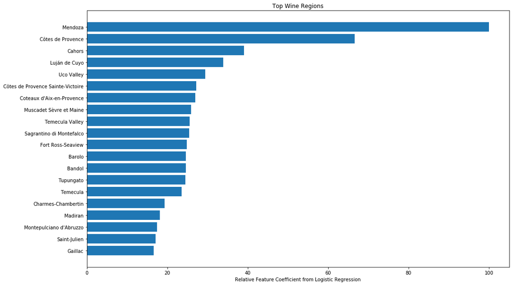

```python
#Top Regions
plot_features('region_1', 'region_1_','', 20, 'Top Wine Regions',True)
```

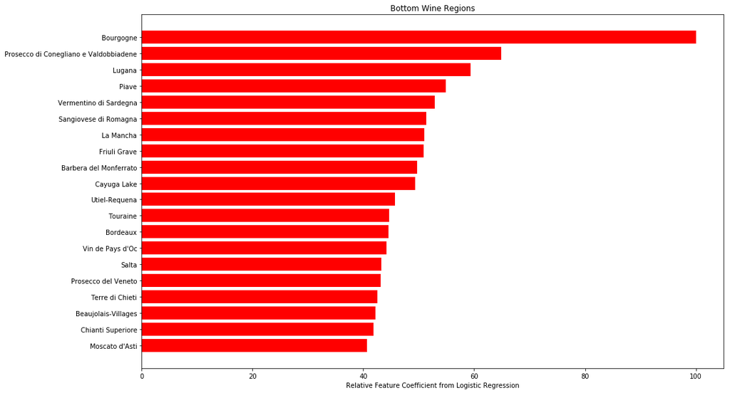

```python
#Bottom Regions
plot_features('region_1', 'region_1_','', 20, 'Bottom Wine Regions',False)
```

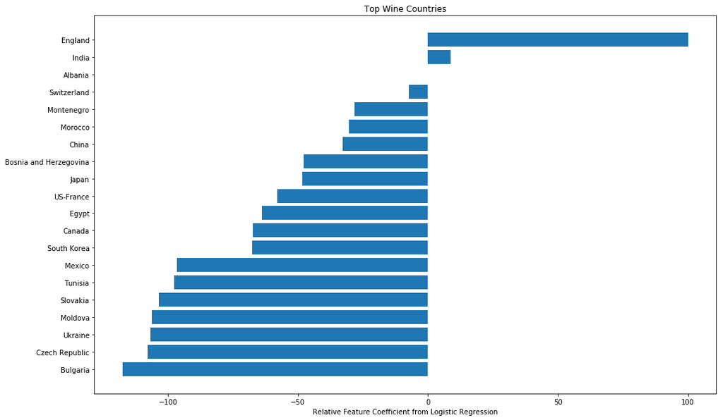

```python
#Top Countries
plot_features('country', 'country_','', 20, 'Top Wine Countries',True)
```

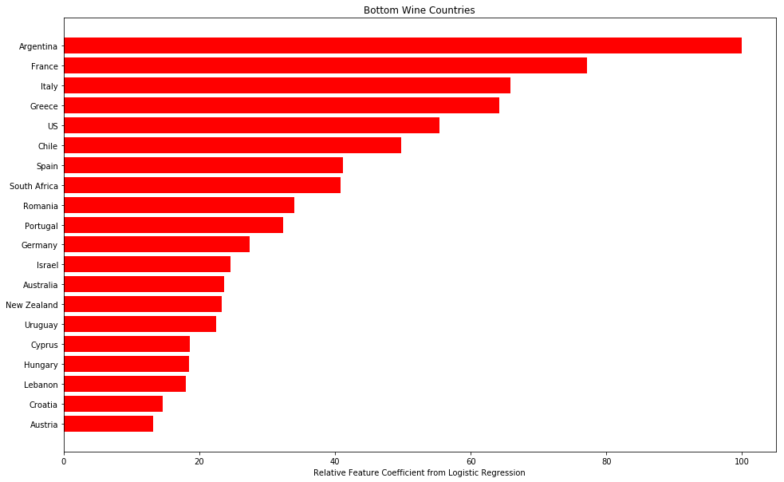

```python
#Bottom Countries
plot_features('country', 'country_','', 20, 'Bottom Wine Countries',False)
```

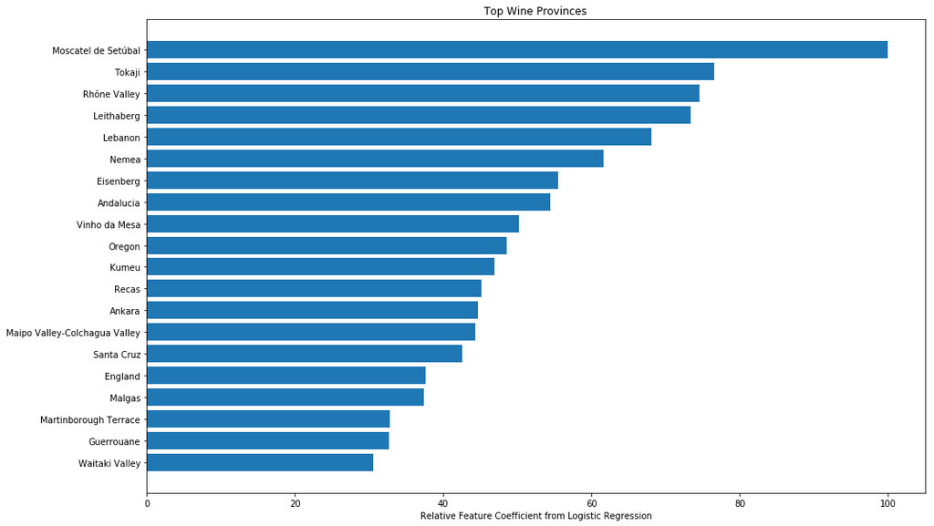

```python
#Top Provinces
plot_features('province', 'province_','', 20, 'Top Wine Provinces',True)
```

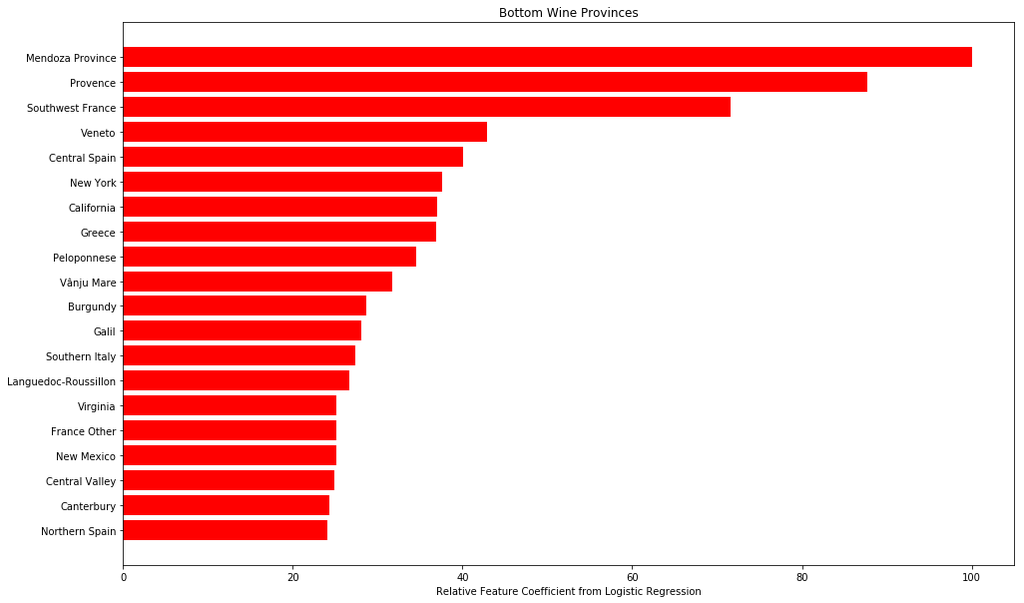

```python
#Bottom Provinces
plot_features('province', 'province_','', 20, 'Bottom Wine Provinces',False)
```

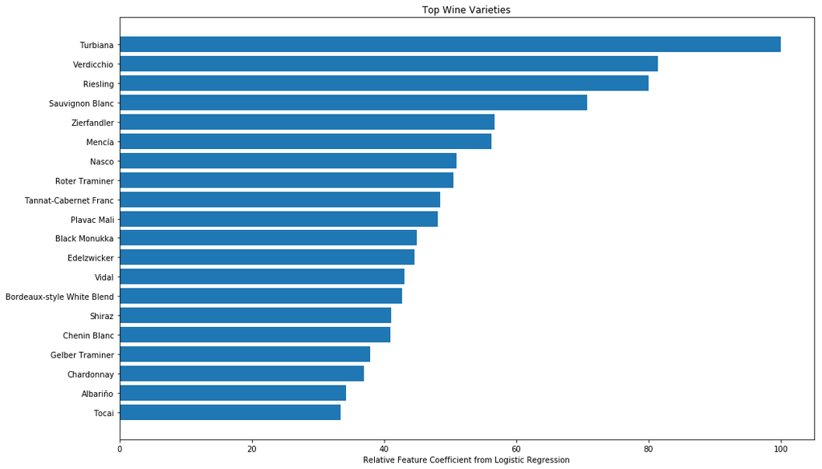

```python
#Top Varieties
plot_features('variety', 'variety_','', 20, 'Top Wine Varieties',True)
```

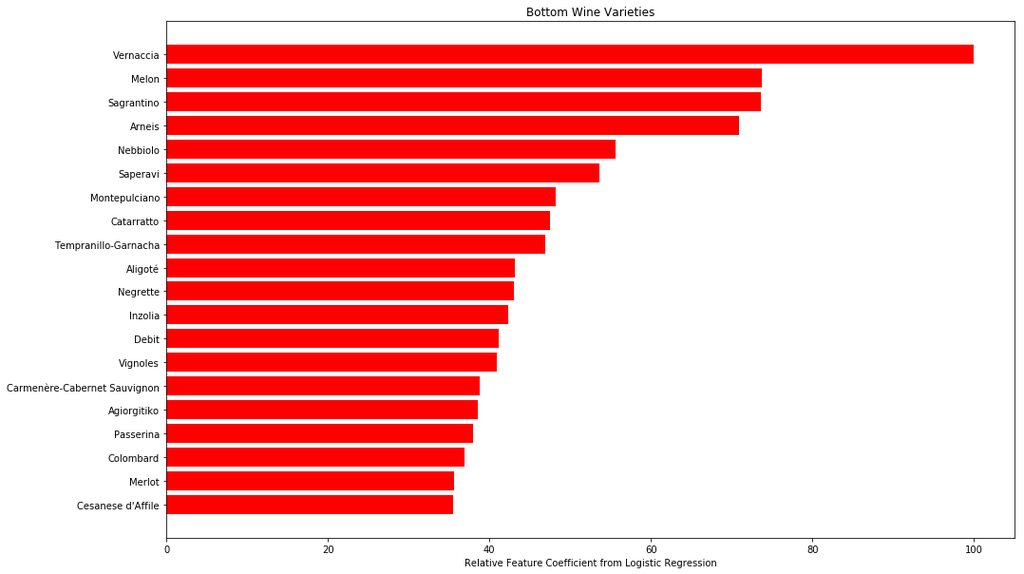

```python
#Bottom Varieties
plot_features('variety', 'variety_','', 20, 'Bottom Wine Varieties',False)
```

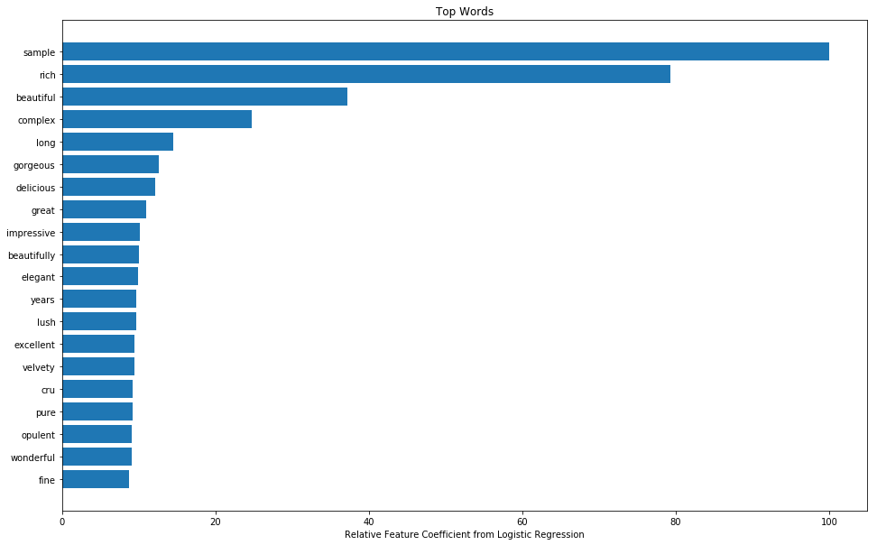

```python
#Top Words
plot_features('', '', ['_','price'],20, 'Top Words',True)
```

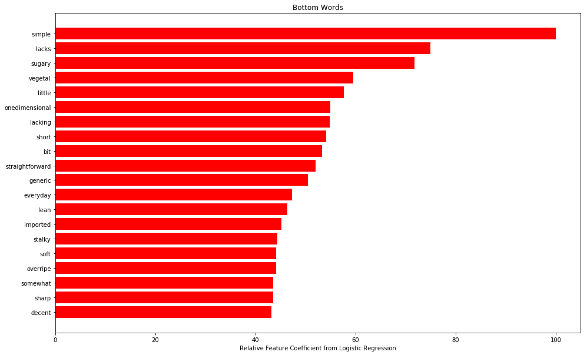

```python
#Bottom Words
plot_features('', '', ['_','price','stopwords','nan'],20, 'Bottom Words',False)
```

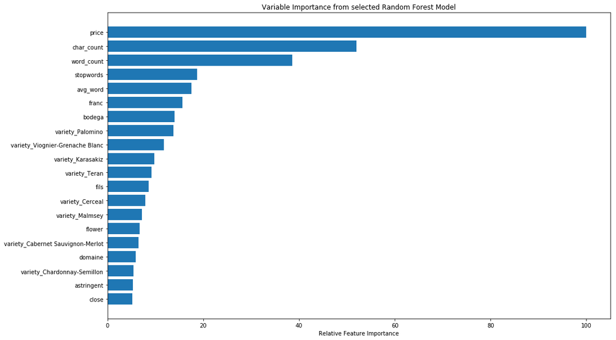

```python
# Make importances relative to max importance.
feature_importance = 100.0 * (feature_importance / feature_importance.max())
sorted_idx = np.argsort(feature_importance)[-20:]
pos = np.arange(sorted_idx.shape[0]) + .5
plt.figure(figsize=(16,10))
plt.barh(pos, feature_importance[sorted_idx], align='center')
plt.yticks(pos, X_train.columns[sorted_idx])
plt.xlabel('Relative Feature Importance')
plt.title('Variable Importance from selected Random Forest Model')
plt.show()
```

## Step 6: Future Steps

1. Trying different model weightings and PCA components to achieve consistency between the training and test set
2. Create a regressor model to predict points, and attempt to maximize the r-squared of the test set, while not overfitting to a training set
3. Evaluating the model's performance when a key variable like price is removed since the price may be derived based on the description and the wine's future potential.

```python
#evaluate random forest using best params above
#Try Random Forest with different number of estimators
rf_filename = r'random_forest_best_params_random_search_no_price.pkl'
pipeline = run_model_no_price('Random Forest using parameters from random search without price', rf_filename, False, False, 0, ensemble.RandomForestClassifier(bootstrap=False, max_depth=80, max_features= 'auto', min_samples_leaf=1, min_samples_split=10,n_estimators=1000, n_jobs=-1))

feature_importance_np = pipeline.named_steps['classifier'].feature_importances_
```

```
Random Forest using parameters from random search without price
Training set (No Price):
             precision    recall  f1-score   support

          0       1.00      1.00      1.00     71824
          1       1.00      1.00      1.00     33827

avg / total       1.00      1.00      1.00    105651

Test set (No Price):
             precision    recall  f1-score   support

          0       0.91      0.96      0.94     30896
          1       0.91      0.80      0.85     14383

avg / total       0.91      0.91      0.91     45279

Accuracy:  0.9098257470350494
--- 130.77624702453613 seconds ---
```

```python
#evaluate random forest using best params above
#Try Random Forest with different number of estimators
rf_filename = r'Ridge_regression.pkl'
pipeline = run_model_points('Ridge Regression', rf_filename, False, False, 0, Ridge())
```

```
Ridge Regression
Training set:
0.7534713911750992
Test set:
0.7407043985488787
--- 33189.15379691124 seconds ---
```

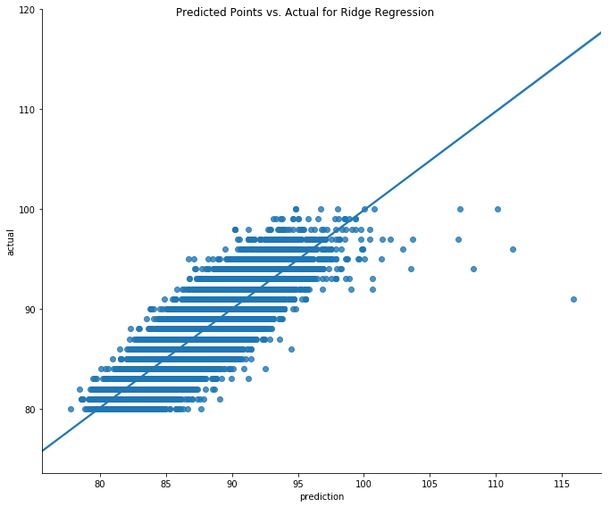

```python
#plt.scatter(pipe.predict(test_inp),test_out)
pred_actual = pd.DataFrame(np.column_stack((pipeline.predict(X_test_points),y_test_points)))

pred_actual.columns = ['prediction','actual']

g = sns.lmplot(x='prediction', y='actual'
               ,fit_reg=True
               ,data=pred_actual, size=8, aspect=1.2)
fig = g.fig

# Add a title to the Figure
fig.suptitle("Predicted Points vs. Actual for Ridge Regression", fontsize=12)
plt.show()
```

[figure not shown]

```python
#Top Coefficients
plot_features_points('', '','', 20, 'Top Coefficients from Ridge Regression',True)
```

[figure not shown]

```python
#Bottom Coefficients
plot_features_points('', '','', 20, 'Bottom Coefficients from Ridge Regression',False)
```